# individual1

Ryan Herren and Carter Meseck

3/4/2021

```r
library(ggplot2)
library(tidyverse)
library(ggpubr)
happy <- readxl::read_xls('/Users/ryanherren/Downloads/GSS.xls')
data <- readxl::read_xls('/Users/ryanherren/Downloads/GSS_Meseck.xls')
```

```r
happy
```

```
## # A tibble: 64,816 x 12
##    `Gss year for this … `General happine… `Belief in life a… `Political party a…
##                   <dbl> <chr>             <chr>              <chr>
##  1                 1972 Not too happy     Not applicable     Ind,near dem
##  2                 1972 Not too happy     Not applicable     Not str democrat
##  3                 1972 Pretty happy      Not applicable     Independent
##  4                 1972 Not too happy     Not applicable     Not str democrat
##  5                 1972 Pretty happy      Not applicable     Strong democrat
##  6                 1972 Pretty happy      Not applicable     Ind,near dem
##  7                 1972 Not too happy     Not applicable     Ind,near dem
##  8                 1972 Not too happy     Not applicable     Ind,near dem
##  9                 1972 Pretty happy      Not applicable     Strong democrat
## 10                 1972 Pretty happy      Not applicable     Strong democrat
## # … with 64,806 more rows, and 8 more variables: Total family income <chr>,
## #   Respondents sex <chr>, Highest year of school completed <chr>,
## #   Number of children <chr>, Marital status <chr>,
## #   Number of hours usually work a week <chr>, Respondent id number <dbl>,
## #   Ballot used for interview <chr>
```

```r
data
```

```
## # A tibble: 64,816 x 5
##    `Marital status` `Highest year of scho… `Respondents se… `Political party af…
##    <chr>            <chr>                  <chr>            <chr>
##  1 Never married    16                     Female           Ind,near dem
##  2 Married          10                     Male             Not str democrat
##  3 Married          12                     Female           Independent
##  4 Married          17                     Female           Not str democrat
##  5 Married          12                     Female           Strong democrat
##  6 Never married    14                     Male             Ind,near dem
##  7 Divorced         13                     Male             Ind,near dem
##  8 Never married    16                     Male             Ind,near dem
##  9 Never married    12                     Female           Strong democrat
## 10 Married          12                     Female           Strong democrat
## # … with 64,806 more rows, and 1 more variable: General happiness <chr>
```

Use ggplot2 to create the plots, and dplyr to manipulate the data frame as much as possible. You may want to rename the columns of the data frame for your convenience using rename in dplyr.

```r
happy <- rename(happy, 'happiness' = 'General happiness')
happy <- rename(happy, 'year' = 'Gss year for this respondent')
happy <- rename(happy, 'belief' = 'Belief in life after death')
happy <- rename(happy, 'party' = 'Political party affiliation')
happy <- rename(happy, 'income' = 'Total family income')
happy <- rename(happy, 'sex' = 'Respondents sex')
happy <- rename(happy, 'education' = 'Highest year of school completed')
happy <- rename(happy, 'num_children' = 'Number of children')
happy <- rename(happy, 'marital' = 'Marital status')
happy <- rename(happy, 'work' = 'Number of hours usually work a week')
happy <- rename(happy, 'id' = 'Respondent id number')
happy <- rename(happy, 'ballot' = 'Ballot used for interview')
```

## Question 1: Find the average years of education for the respondents with each marital status. Arrange your output in a meaningful order and print. Describe any patterns you find.

```r
happy %>%
  group_by(marital) %>%
    summarise(
        count = n(),
        mean_education = mean(as.numeric(education), na.rm = T),
    )
```

```
## # A tibble: 7 x 3
##   marital       count mean_education
## * <chr>         <int>          <dbl>
## 1 Divorced       8379           13.1
## 2 Married       34129           13.0
## 3 Never married 13837           13.4
## 4 No answer        27           15.5
## 5 Separated      2242           11.9
## 6 Widowed        6200           11.2
## 7 <NA>              2          NaN
```

By looking at the results, it is hard to draw any conclusions. Statistically, the lower your education, the more likely you are to be widowed, which isn’t exactly scientific. Divorced, married, and never married are all about the same in terms of average education. There is not significant evidence that education can predict marital status.

## Question 2: Create a single data frame containing records for the better educated respondents with each marital status. A “better educated” respondent is someone who has strictly more years of education than the average among those with the same marital status. Print the structure of the data frame.

```r
smart_divorced <- select(filter(filter(happy, marital == "Divorced"), as.numeric(education) > 13.1), happiness, year, belief, party, income, sex, education, num_children, marital, work, id, ballot)
smart_married <- select(filter(filter(happy, marital == "Married"), as.numeric(education) > 13.0), happiness, year, belief, party, income, sex, education, num_children, marital, work, id, ballot)
smart_never_married <- select(filter(filter(happy, marital == "Never married"), as.numeric(education) > 13.4), happiness, year, belief, party, income, sex, education, num_children, marital, work, id, ballot)
smart_separated <- select(filter(filter(happy, marital == "Separated"), as.numeric(education) > 11.9), happiness, year, belief, party, income, sex, education, num_children, marital, work, id, ballot)
smart_widowed <- select(filter(filter(happy, marital == "Widowed"), as.numeric(education) > 11.1), happiness, year, belief, party, income, sex, education, num_children, marital, work, id, ballot)
educated <- rbind(smart_divorced, smart_married, smart_never_married, smart_separated, smart_widowed)
str(educated)
```

```
## tibble [28,132 × 12] (S3: tbl_df/tbl/data.frame)
##  $ happiness   : chr [1:28132] "Very happy" "Very happy" "Pretty happy" "Pretty happy" ...
##  $ year        : num [1:28132] 1972 1972 1972 1972 1972 ...
##  $ belief      : chr [1:28132] "Not applicable" "Not applicable" "Not applicable" "Not applicable" ...
##  $ party       : chr [1:28132] "Ind,near rep" "Not str democrat" "Ind,near rep" "Not str democrat" ...
##  $ income      : chr [1:28132] "Not applicable" "Not applicable" "Not applicable" "Not applicable" ...
##  $ sex         : chr [1:28132] "Male" "Female" "Female" "Male" ...
##  $ education   : chr [1:28132] "15" "16" "14" "20" ...
##  $ num_children: chr [1:28132] "0" "0" "5" "0" ...
##  $ marital     : chr [1:28132] "Divorced" "Divorced" "Divorced" "Divorced" ...
##  $ work        : chr [1:28132] "Not applicable" "Not applicable" "Not applicable" "Not applicable" ...
##  $ id          : num [1:28132] 83 109 177 245 657 ...
##  $ ballot      : chr [1:28132] "Not applicable" "Not applicable" "Not applicable" "Not applicable" ...
```

## Question 3: How is the happiness of a respondent related to his/her marriage status? Define that a person is happy if the response to question is “Very happy” or “Pretty happy”.

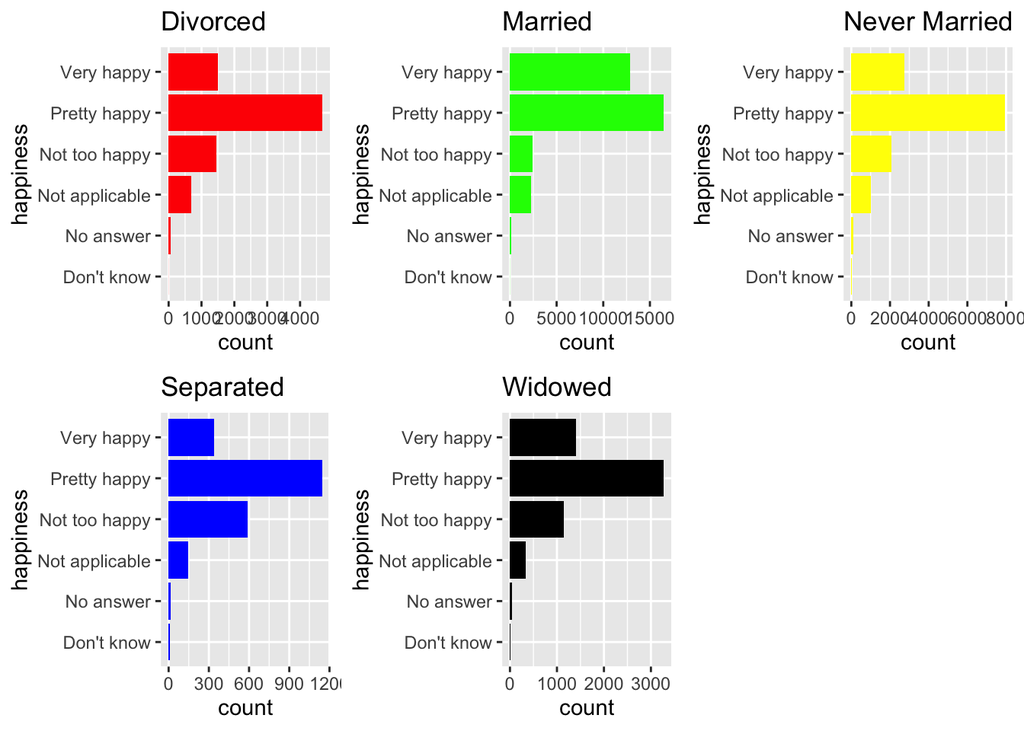

```r
divorced = select(filter(happy, marital == "Divorced"), happiness, year, belief, party, income, sex, education, num_children, marital, work, id, ballot)
married = select(filter(happy, marital == "Married"), happiness, year, belief, party, income, sex, education, num_children, marital, work, id, ballot)
never_married = select(filter(happy, marital == "Never married"), happiness, year, belief, party, income, sex, education, num_children, marital, work, id, ballot)
separated = select(filter(happy, marital == "Separated"), happiness, year, belief, party, income, sex, education, num_children, marital, work, id, ballot)
widowed = select(filter(happy, marital == "Widowed"), happiness, year, belief, party, income, sex, education, num_children, marital, work, id, ballot)

# divorced %>%
#   summarise(
#     divorced_count = n(),
#   )
# divorced_happy <- filter(divorced, happiness == "Very happy" | happiness == "Pretty happy")
# divorced_happy %>%
#   summarise(
#     hd_count = n()
#   )

div <- ggplot(divorced, aes(x=happiness)) + geom_bar(fill='red') + coord_flip() + ggtitle("Divorced")
mar <- ggplot(married, aes(x=happiness)) + geom_bar(fill='green') + coord_flip() + ggtitle("Married")
nev <- ggplot(never_married, aes(x=happiness)) + geom_bar(fill='yellow') + coord_flip() + ggtitle("Never Married")
sep <- ggplot(separated, aes(x=happiness)) + geom_bar(fill='blue') + coord_flip() + ggtitle("Separated")
wid <- ggplot(widowed, aes(x=happiness)) + geom_bar(fill='black') + coord_flip() + ggtitle("Widowed")
figure <- ggarrange(div, mar, nev, sep, wid)
figure
```

Based off of the proportions of the charts, married people are most likely to be very happy. Separated people have the highest proportion of not too happy people.

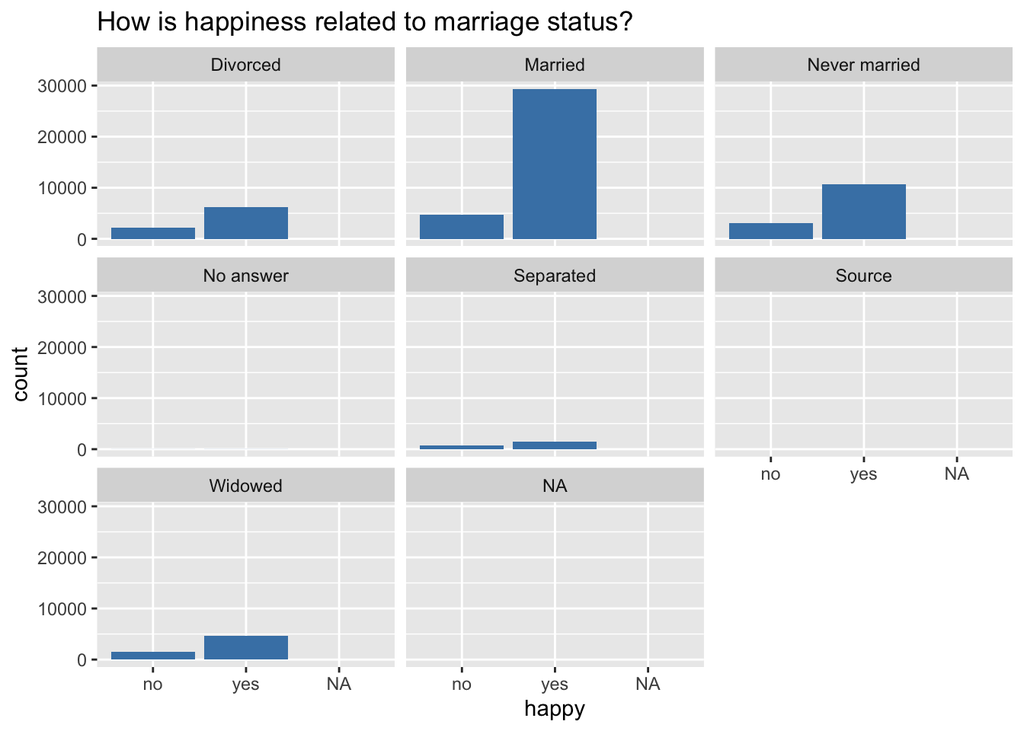

```r
### Problem 3, how is happiness related to marriage status?

data$happy <- ifelse(data$`General happiness`== 'Pretty happy' | data$`General happiness` == 'Very happy', 'yes', 'no')

ggplot(aes(x=happy), data=data) + geom_bar(fill="steelblue") + facet_wrap(~ `Marital status`) + ggtitle("How is happiness related to marriage status?")
```

```r
sep <- data[data$`Marital status` == 'Separated',]
table(sep$happy)
```

```
##
##   no  yes
##  755 1487
```

```r
widowed <- data[data$`Marital status` == 'Widowed',]
table(widowed$happy)
```

```
##
##   no  yes
## 1525 4675
```

```r
table(data$happy, data$`Marital status`)
```

```
##
##       Divorced Married Never married No answer Separated Source Widowed
##   no      2199    4787          3151        11       755      0    1525
##   yes     6180   29342         10686        16      1487      0    4675
```

After looking at graphs and numerical summaries for happiness based on each marital status from the data, I can definitely say that your happiness is dependent on your marital status. It seems that people who are married or never married have a significantly higher difference between the people who are happy vs non happy. People who were divorced, separated, or widowed are significantly less happy, and people that have been separated are the most unhappy.

## Question 4: Does party affiliation affect the relationship you found in the last question?

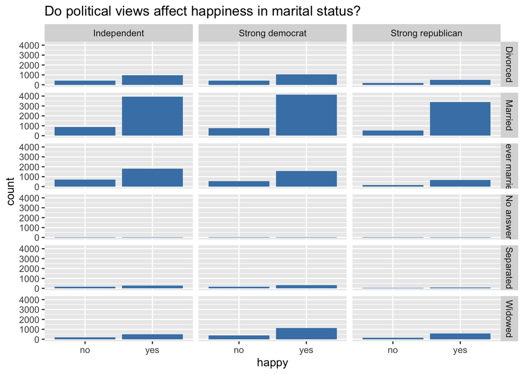

```r
# Q4 - does party affiliation affect Q3

# Too many variables too properly visualize facet_grid, so going to use most strong ones.
q4 <- data[data$`Political party affiliation` %in% c('Independent','Strong democrat', 'Strong republican'),]

ggplot(aes(x=happy), data=q4) + geom_bar(fill="steelblue") + facet_grid(`Marital status` ~ `Political party affiliation`) + ggtitle("Do political views affect happiness in marital status?")
```

```r
table(q4$`Political party affiliation`, q4$happy)
```

```
##
##                       no  yes
##   Independent       2347 7541
##   Strong democrat   2199 8179
##   Strong republican 1080 5238
```

```r
table(q4$`Marital status`, q4$`Political party affiliation`)
```

```
##
##                 Independent Strong democrat Strong republican
##   Divorced             1402            1444               686
##   Married              4819            4885              3941
##   Never married        2508            2098               827
##   No answer               6               2                 2
##   Separated             439             457               127
##   Widowed               714            1492               735
```

## Question 5: How is marital status related to the education of a respondent? What are possible reasons accounting for the patterns you see?

```r
table(data$`Highest year of school completed`)
```

```
##
##                                                                 0
##                                                               165
##                                                                 1
##                                                                47
##                                                                10
##                                                              2880
##                                                                11
##                                                              3743
##                                                                12
##                                                             19663
##                                                                13
##                                                              5360
##                                                                14
##                                                              7160
##                                                                15
##                                                              2910
##                                                                16
##                                                              8355
##                                                                17
##                                                              1967
##                                                                18
##                                                              2384
##                                                                19
##                                                               920
##                                                                 2
##                                                               152
##                                                                20
##                                                              1439
##                                                                 3
##                                                               257
##                                                                 4
##                                                               319
##                                                                 5
##                                                               402
##                                                                 6
##                                                               828
##                                                                 7
##                                                               879
##                                                                 8
##                                                              2724
##                                                                 9
##                                                              2083
## Data collection: General Social Survey\nCase Selection: all cases
##                                                                 1
##                                                        Don't know
##                                                                73
##                                                         No answer
##                                                               104
```

```r
data <- filter(data, !`Highest year of school completed` %in% c('No answer',"Don't know","Data collection: General Social Survey\nCase Selection: all cases"))
table(data$`Highest year of school completed`)
```

```
##
##     0     1    10    11    12    13    14    15    16    17    18    19     2
##   165    47  2880  3743 19663  5360  7160  2910  8355  1967  2384   920   152
##    20     3     4     5     6     7     8     9
##  1439   257   319   402   828   879  2724  2083
```

```r
data <- data %>% mutate(`Highest year of school completed` = as.numeric(`Highest year of school completed`))



apart <- data[data$`Marital status` %in% c('Divorced','Widowed','Separated','Never married'),]

together <- data[data$`Marital status` %in% c('Married'),]

together %>% arrange((`Highest year of school completed`))
```

```
## # A tibble: 34,053 x 6
##    `Marital status` `Highest year of scho… `Respondents se… `Political party af…
##    <chr>                             <dbl> <chr>            <chr>
##  1 Married                               0 Male             Strong democrat
##  2 Married                               0 Female           Strong democrat
##  3 Married                               0 Male             Strong democrat
##  4 Married                               0 Female           Not str democrat
##  5 Married                               0 Male             Strong democrat
##  6 Married                               0 Male             Strong republican
##  7 Married                               0 Male             Strong democrat
##  8 Married                               0 Male             No answer
##  9 Married                               0 Male             Independent
## 10 Married                               0 Female           No answer
## # … with 34,043 more rows, and 2 more variables: General happiness <chr>,
## #   happy <chr>
```

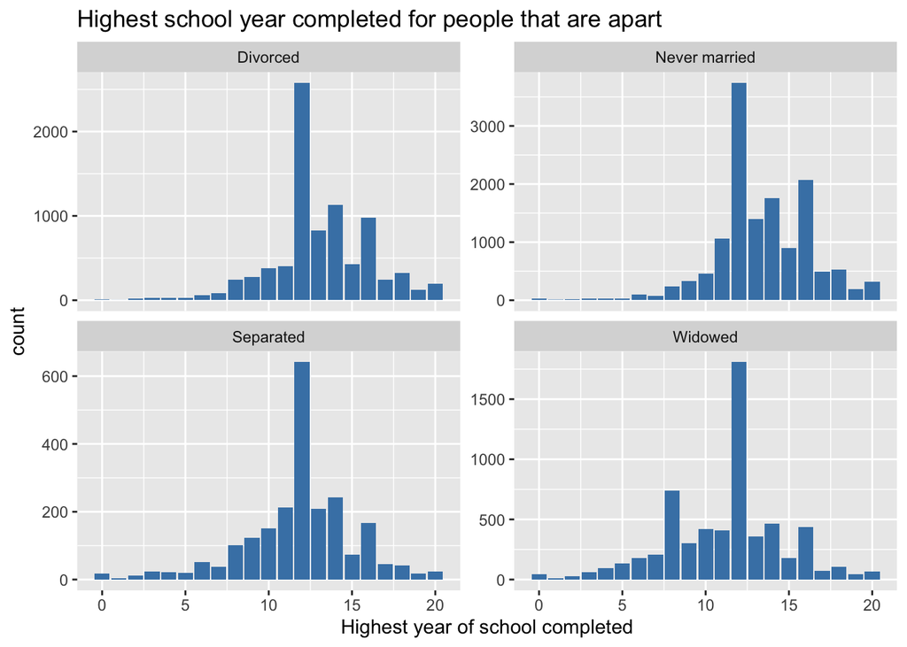

```r
ggplot(aes(x=`Highest year of school completed`), data=apart) + geom_bar(fill="steelblue") + facet_wrap(~ `Marital status`, scales = "free_y") + ggtitle("Highest school year completed for people that are apart")
```

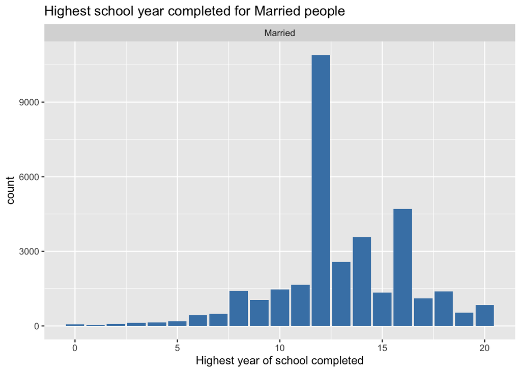

```r
ggplot(aes(x=`Highest year of school completed`), data=together) + geom_bar(fill="steelblue") + facet_wrap(~ `Marital status`, scales = "free_y") + ggtitle("Highest school year completed for Married people")
```

```r
summary(together$`Highest year of school completed`)
```

```
##    Min. 1st Qu.  Median    Mean 3rd Qu.    Max.
##    0.00   12.00   12.00   12.97   16.00   20.00
```

```r
summary(apart$`Highest year of school completed`)
```

```
##    Min. 1st Qu.  Median    Mean 3rd Qu.    Max.
##    0.00   12.00   12.00   12.76   15.00   20.00
```

## Question 6: Explore two more interesting questions, and answer those questions using the GSS data.

## Question 6 Part 1: I am going to be exploring if sex affects how happy you are depending on marital status. e.g are single/married males happier than females, etc.

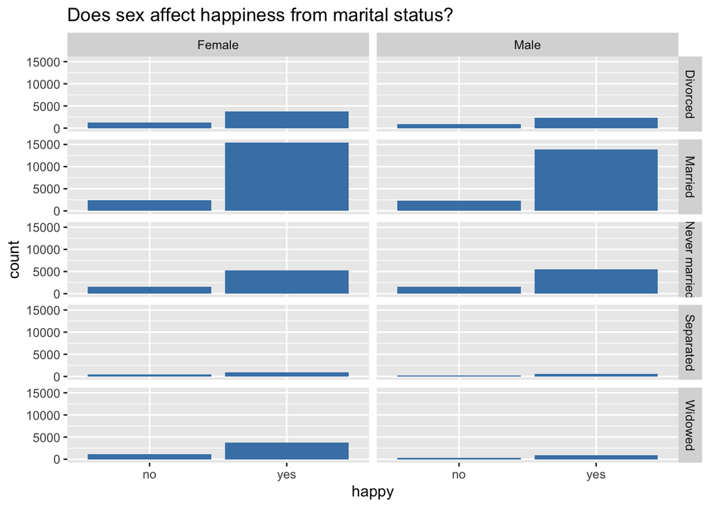

```r
data <- filter(data, !`Respondents sex` %in% c(NA))
data <- filter(data, !`Marital status` %in% c(NA, "No answer"))

ggplot(aes(x=happy), data=data) + geom_bar(fill="steelblue") + facet_grid(`Marital status` ~ `Respondents sex`) + ggtitle("Does sex affect happiness from marital status?")
```

```r
summary(data$happy)
```

```
##    Length     Class      Mode
##     64614 character character
```

```r
table(data$happy, data$`Marital status`)
```

```
##
##       Divorced Married Never married Separated Widowed
##   no      2194    4768          3136       751    1515
##   yes     6169   29285         10665      1482    4649
```

```r
table(data$happy, data$`Respondents sex`)
```

```
##
##       Female  Male
##   no    6937  5427
##   yes  29144 23106
```

```r
table(data$`Marital status`, data$`Respondents sex`)
```

```
##
##                 Female  Male
##   Divorced        5068  3295
##   Married        17856 16197
##   Never married   6748  7053
##   Separated       1428   805
##   Widowed         4981  1183
```

```r
# After looking at the graphs and numerical summaries, sex doesn't appear to make a difference in if someone is more likely to be happy with their marital status.
```

## Question 6 Part 2: I am going to explore is if income has any effect on how happy someone is.

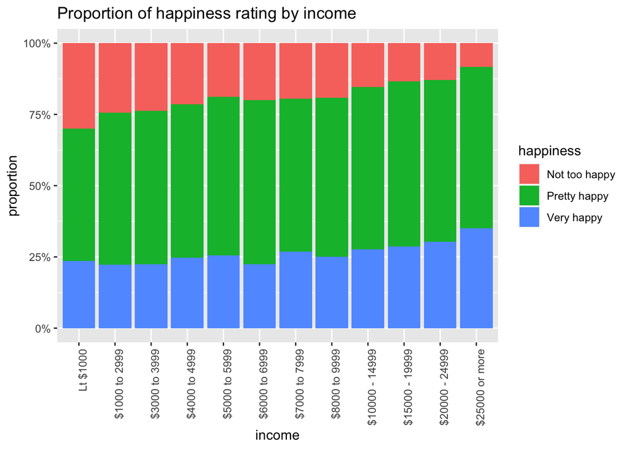

```r
cleaned_happy <- subset(happy, happiness!="No answer" & happiness != "Don't know" & happiness != "Data collection: General Social Survey\nCase Selection: all cases" & income != "No answer" & income != "Not applicable" & income != "Refused" & income != "Don't know" & happiness != 'Not applicable')
p <- ggplot(cleaned_happy, aes(fill = happiness, x = income)) + geom_bar(position='fill') + scale_y_continuous(labels = scales::percent) + scale_x_discrete(limits = c("Lt $1000","$1000 to 2999", '$3000 to 3999', '$4000 to 4999', '$5000 to 5999', '$6000 to 6999', '$7000 to 7999', '$8000 to 9999', '$10000 - 14999', '$15000 - 19999', '$20000 - 24999', '$25000 or more'))
p + theme(axis.text.x = element_text(angle = 90, hjust = 1)) + ggtitle("Proportion of happiness rating by income") + ylab("proportion")
```

Based off of the stacked bar chart, it is obvious that you are more likely to be more happy as your income increases. For the most part, the proportion of people who are pretty happy stays the same, but people switch from not too happy to very happy